# AI for Beginners: Crafting a Chatbot to Transform Customer Service

## 1) Introduction

### 1.1) Chatbots in Customer Service

- Chatbots help out with simple stuff, giving customer service reps more time for tricky issues.
- Customers get quick answers to basic questions without waiting for a human rep.
- Chatbots can be the initial contact point that ensures all the information required from the customer is available

### 1.2) Alternatives to Chatbots

- Human support (costly and may not be 24/7)
- Community forums (not necessarily accurate, may not properly represent the brand)
- Videos/tutorials/FAQs (may not be comprehensive, may need to look in multiple places to get the complete answer)

### 1.3) Implementing a chatbot with an LLM

- Data cleaning, storage, retrival, formatting
- Prompts
- Embeddings
- LLM
- Conversation memory
- Completion

[figure not shown]

## 2) Setup the environment

- LLM
  - [OpenAI API keys](https://platform.openai.com/account/api-keys) and add to .env file
    - ChatGPT Plus ($20) does not give you API access. They are seperate products and each API query costs money
    - API access does not give you GPT4, there is a waitlist for GPT4
  - FREE: [Huggingface API keys (optional)](https://huggingface.co/settings/tokens) and add to .env file
    - Free
    - Smaller models which can be less accurate
    - Can be less accurate
- Vector databases
  - FAISS
    - In memory
    - Free
  - Pinecone
    - Has a free tier that works for most cases
- pip install from requirements file

```python
%pip install -r requirements.txt
!python -m pip install python-dotenv
```

```python
import pandas as pd
import re
import numpy as np
from tqdm import tqdm
import os
import pickle

import openai
import tiktoken

from langchain.llms import OpenAI
from langchain import LLMChain
from langchain.embeddings.huggingface import HuggingFaceEmbeddings
from langchain.embeddings.openai import OpenAIEmbeddings
from langchain.vectorstores import FAISS, Pinecone
from langchain import PromptTemplate

import pinecone

import matplotlib.pyplot as plt
import plotly.graph_objs as go
import plotly.io as pio
import textwrap
from sklearn.cluster import KMeans
from sklearn.manifold import TSNE

# LOAD ENVIRONMENT VARIABLES FROM THE .env FILE
from dotenv import load_dotenv
load_dotenv()

# Get API key from environment variables
api_key = os.getenv('OPENAI_API_KEY')

# Set OpenAI API key
openai.api_key = api_key
```

## 3) Prep the data

- Get data from Kaggle
- Clean data
- Organize into chat inputs
- Exploratory Data Analysis

[figure not shown]

```python
# https://www.kaggle.com/datasets/thoughtvector/customer-support-on-twitter
# /kaggle/input/customer-support-on-twitter/twcs/twcs.csv

def extract_company(row):
    if not row['inbound']:
        return row['author_id']
    else:
        match = re.search(r"@(\w+)", row['text'])
        if match:
            return match.group(1)
        else:
            return None

def get_tweets_df(csv_file):
    tweets = pd.read_csv(csv_file, encoding='utf-8')

    # Fill missing values with -1
    tweets['in_response_to_tweet_id'] = tweets['in_response_to_tweet_id'].fillna(-1)
    tweets['response_tweet_id'] = tweets['response_tweet_id'].fillna(-1)

    tweets['in_response_to_tweet_id'] = tweets['in_response_to_tweet_id'].astype(int)

    # Add a new column for the associated company
    tweets['company'] = tweets.apply(extract_company, axis=1)

    return tweets

csv_file = './input/twcs/twcs_tail.csv'
# csv_file = './input/twcs/sample.csv'
tweets = get_tweets_df(csv_file)
print(f"tweets: {tweets.shape}")
tweets.head(5)
```

```
tweets: (35026, 8)
```

|  | tweet_id | author_id | inbound | created_at | text | response_tweet_id | in_response_to_tweet_id | company |
| --- | --- | --- | --- | --- | --- | --- | --- | --- |
| 0 | 2917710 | 740946 | True | Tue Nov 28 23:46:57 +0000 2017 | .@115873 if I get a 1-star rating from a passe... | 2917708 | -1 | 115873 |
| 1 | 2917714 | Uber_Support | False | Wed Nov 29 00:25:55 +0000 2017 | @291914 We're here to help! Send us a DM with ... | -1 | 456807 | Uber_Support |
| 2 | 456807 | 291914 | True | Wed Nov 29 00:23:49 +0000 2017 | @McDonalds @115877 Yeah. Your ad needs fixing ... | 2917714 | 456625 | McDonalds |
| 3 | 2917715 | Uber_Support | False | Wed Nov 29 00:24:21 +0000 2017 | @605407 Here to help. Send us a note at https:... | 2917716 | 2917717 | Uber_Support |
| 4 | 2917716 | 605407 | True | Wed Nov 29 00:28:42 +0000 2017 | @Uber_Support this feels like a really slow pr... | 2917718 | 2917715 | Uber_Support |

### Convert the dataframe into conversation threads

```python
def get_conversation_threads(tweet_id, df, company=None):
    conversation = []
    timestamps = []
    inbound_status = []

    while tweet_id:
        rows = df.loc[df['tweet_id'] == tweet_id]
        if not rows.empty:
            row = rows.squeeze()

            # Filter out tweets not associated with the specified company
            if company is not None and row['company'] != company:
                tweet_id = None
                continue

            conversation.append(tweet_id)
            timestamps.append(pd.to_datetime(row['created_at']))
            inbound_status.append(row['inbound'])

            if pd.notna(row["response_tweet_id"]):
                tweet_id = int(str(row["response_tweet_id"]).split(',')[0])
            elif pd.notna(row["in_response_to_tweet_id"]):
                tweet_id = int(str(row["in_response_to_tweet_id"]).split(',')[0])
            else:
                tweet_id = None
        else:
            tweet_id = None

    sorted_conversation = sorted(zip(conversation, timestamps, inbound_status), key=lambda x: x[1])
    return [(tweet_id, inbound) for tweet_id, _, inbound in sorted_conversation]



specific_company = "SouthwestAir"

# Initialize an empty list to store conversation threads text
threads_text = []
for index, row in tqdm(tweets.iterrows(), total=tweets.shape[0]):

    tweet_id = row['tweet_id']
    conversation_thread = get_conversation_threads(tweet_id, tweets, specific_company)
    if len(conversation_thread)==0:
        continue

    # CONVERT INTO THE EXPECTED TEXT FORMAT
    thread_text = ""
    for chain_id, inbound in conversation_thread:
        text = tweets.loc[tweets['tweet_id'] == chain_id, 'text'].values[0]
        try:
            content = text.split(': ')[1]
        except IndexError:
            content = text
        if inbound:
            modified_text = f"USER-->\n{content}\n"
        else:
            modified_text = f"<--SUPPORT\n{content}\n"

        thread_text += (modified_text)

    threads_text.append(thread_text)


print(threads_text[12])
```

```
100%|██████████████████████████████████████████████████████████████████████████████████████████████████████████████████████████████████████████████████████████████████████████| 35026/35026 [00:08<00:00, 4076.89it/s]
```

```
USER-->
@SouthwestAir thanks for the ride over to LAX this evening. As always, great service. Cheers! https://t.co/Kba49stGIo
<--SUPPORT
@155613 Always a pleasure having you onboard with us, Mike. Come back and see us again soon! ^MA
```

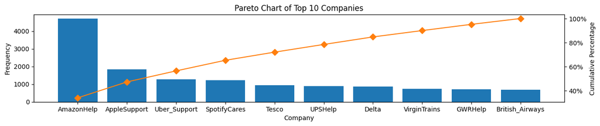

```python
# EXPLORATORY DATA ANALYSIS

# Assuming your DataFrame is named 'df'
company_counts = tweets['company'].value_counts().nlargest(10)
total_counts = company_counts.sum()

cumulative_percentage = (company_counts.cumsum() / total_counts) * 100

# Plot the Pareto chart
fig, ax = plt.subplots(figsize=(15, 2.5))
ax.bar(company_counts.index, company_counts.values, color='C0')
ax2 = ax.twinx()
ax2.plot(cumulative_percentage.index, cumulative_percentage.values, color='C1', marker='D', ms=7)
ax2.yaxis.set_major_formatter(plt.FuncFormatter(lambda x, _: '{:.0%}'.format(x/100)))

ax.set_xlabel('Company')
ax.set_ylabel('Frequency')
ax2.set_ylabel('Cumulative Percentage')
plt.title('Pareto Chart of Top 10 Companies')
plt.show()
```

## 4) Embeddings and Vectorstore Database

- Embeddings are low dimensional representation of high dimensional data (like language)
- For the chatbot we need a lower dimensional representation of the customer support exchange
- We can generate embeddings with OpenAI, HuggingFace, etc.
- 1) Convert conversations into embeddings
- 2) Store embeddings in a vector database
- 3) Convert a query to embeddings
- 4) Find similar conversations to the query

[figure not shown]

### Create the embeddings

```python
use_openai_embeddings = True

if use_openai_embeddings:
   #2 SECONDS
   embed_model = "text-embedding-ada-002" # 1536 dimensions

   embedding_results = openai.Embedding.create(
      input=threads_text, engine=embed_model
   )

   embedding_matrix = []
   for x in embedding_results['data'] :
      embedding_matrix.append(x['embedding'])

   # USED FOR VISUALIZATION
   embedding_array = np.array(embedding_matrix)

else:

   # RUNS FOR 125 SECONDS
   model_name = "sentence-transformers/all-mpnet-base-v2"
   model_kwargs = {"device": "cpu"}
   embeddings = HuggingFaceEmbeddings(model_name=model_name, model_kwargs=model_kwargs)

   embedding_results_hf = embeddings.embed_documents(threads_text)

   # USED FOR VISUALIZATION
   embedding_array = np.array(embedding_results_hf)

pickle_file = 'input/embeddings/faiss_db.pkl'

if os.path.exists(pickle_file):
   print(f"Load the pkl file: {pickle_file}")
   with open(pickle_file, 'rb') as f:
      db = pickle.load(f)
else:
   if use_openai_embeddings:
      # TAKES 40 SECONDS
      db = FAISS.from_texts(threads_text, OpenAIEmbeddings())
   else:
      # TAKES 125 SECONDS
      db = FAISS.from_texts(threads_text, embeddings)

   # Store the database to a pickle file
   with open(pickle_file, 'wb') as f:
      pickle.dump(db, f)
```

```
Load the pkl file: input/embeddings/faiss_db.pkl
```

### Store the embeddings into a Pinecone Vector Database

```python
# CHOOSE THE DOCUMENT STORE
# use_pinecone_vectorstore = True

# if use_pinecone_vectorstore:
#    pinecone.init()

#    # THE EMBEDDING DIMENSIONS ARE 768 FOR HUGGINGFACE AND 1536 FOR OPENAI
#    # THE INDEX IS CREATED WITH THE CORRECT DIMENSIONS AND CANT BE CHANGED
#    if use_openai_embeddings:
#       dimensions = 1536
#    else:
#       dimensions = 768

#    index_name = "off-to-nanny"
#    if index_name not in pinecone.list_indexes():
#       print(f"Missing index {index_name}. Creating it now.")
#       pinecone.create_index(index_name, dimension=1536)

#    # TAKES 40 SECONDS
#    db = Pinecone.from_texts(threads_text, OpenAIEmbeddings(), index_name="off-to-nanny", namespace="startup-gpt-enumerated-user-responses")
```

### Visualize the embeddings

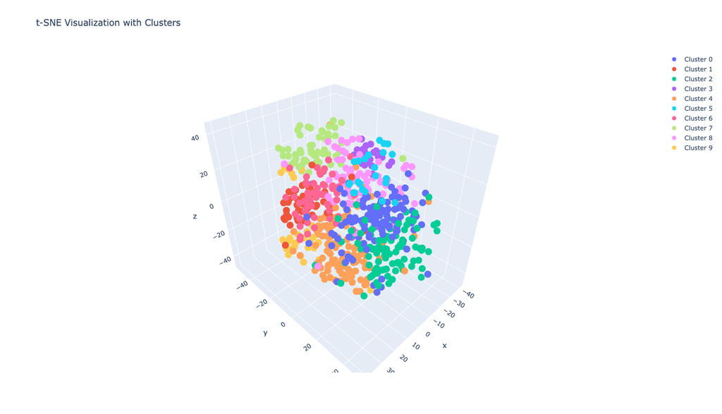

```python
# TO GET AROUND THE nbformat ERROR
#pio.renderers.default = 'browser'
# pio.renderers.default = 'notebook'
pio.renderers.default = 'jupyterlab'

visualization_type = "3d"
# visualization_type = "2d"

# Change number of components to 3
tsne = TSNE(n_components=3, random_state=0)
tsne_obj = tsne.fit_transform(embedding_array)

# Add third component to DataFrame
tsne_df = pd.DataFrame({'Component 1': tsne_obj[:, 0], 'Component 2': tsne_obj[:, 1], 'Component 3': tsne_obj[:, 2], 'Text': threads_text})

# Number of clusters you want to create
n_clusters = 10

# Perform K-means clustering on the embeddings
kmeans = KMeans(n_clusters=n_clusters, random_state=0, n_init = n_clusters).fit(embedding_array)

# Add the cluster labels to the t-SNE DataFrame
tsne_df['Cluster'] = kmeans.labels_

# Function to wrap text with a specified line length
def wrap_text(text, line_length=50):
    return "<br>".join(textwrap.wrap(text, width=line_length))

tsne_df['WrappedText'] = tsne_df['Text'].apply(wrap_text)

# Create a scatter plot with hover text
fig = go.Figure()

# Add a trace for each cluster
for cluster in range(n_clusters):
    cluster_data = tsne_df[tsne_df['Cluster'] == cluster]

    if visualization_type == "3d":
        fig.add_trace(go.Scatter3d(
            x=cluster_data['Component 1'],
            y=cluster_data['Component 2'],
            z=cluster_data['Component 3'],  # Add the third component
            mode='markers',
            hovertemplate='%{text}',
            text=cluster_data['WrappedText'],
            name=f'Cluster {cluster}'
        ))
    else:
        fig.add_trace(go.Scatter(
            x=cluster_data['Component 1'],
            y=cluster_data['Component 2'],
            mode='markers',
            hovertemplate='%{text}',
            text=cluster_data['WrappedText'],
            name=f'Cluster {cluster}'
        ))

# Set the title for the plot
fig.update_layout(
    title='t-SNE Visualization with Clusters',
    height=800
    )

# Show the plot
fig.show()
```

```python
query = "USER-->\n You lost my bag."
# filtered_docs = db_huggingface.similarity_search(query, k=10)
filtered_docs = db.similarity_search(query, k=4)
print(len(filtered_docs))
for doc in (filtered_docs):
   print(doc.page_content)
```

```
4
USER-->
@SouthwestAir if you could find my bag that never made it to baggage claim yesterday on a 1hr flight from Bur to Phx I would be extremely grateful 🙏🏾
<--SUPPORT
@808962 We're very sorry to hear this, Chad. Were you able to file a baggage report with an Agent at the airport? ^MA
USER-->
@SouthwestAir I did, but I’m still just waiting for a call hoping that they found my stuff. All my sweats were in there and it’s cold in Arizona right now.
<--SUPPORT
@808962 We can sympathize with the frustration. Rest assured our Baggage Team is working hard to reunite you with your bag (especially your seats) and will give you a ring as soon as we have any update. We truly appreciate your patience. ^MA

<--SUPPORT
@306262 Oh no! We're sorry to hear that, David. Please be sure to file a report with the local Baggage Service Office, so we can get it back to you ASAP. ^KD

USER-->
@SouthwestAir I did, but I’m still just waiting for a call hoping that they found my stuff. All my sweats were in there and it’s cold in Arizona right now.
<--SUPPORT
@808962 We can sympathize with the frustration. Rest assured our Baggage Team is working hard to reunite you with your bag (especially your seats) and will give you a ring as soon as we have any update. We truly appreciate your patience. ^MA

USER-->
@SouthwestAir My parents waited until 12:30 am to get their bags, they were told they had no other choice and it was their fault.
```

## 5) Prompts

- Give some context on how the LLM should represent itself (customer support agent)
- Provide some examples on how to answer the question

[figure not shown]

### Prompt without memory

```python
# create the length function
def tiktoken_len(text, model_name):
    tokenizer = tiktoken.encoding_for_model(model_name)
    tokens = tokenizer.encode(
        text,
        disallowed_special=()
    )
    return len(tokens)


template = """
You are a friendly and helpful customer support representative named AIrene.
You have been tasked with helping a customer by responding to their query.
Only use information from the previous questions and answers to help you answer the customer's question.

---

Here is their query:
{question}

---

Here are some previous questions and answers that may be helpful to you:
{references}
"""

prompt = PromptTemplate(
    input_variables=["question", "references"],
    template=template,
)

question = "USER-->\n You lost my bag."

references = ""
filtered_docs = db.similarity_search(question, k=10)
for doc in (filtered_docs):
   references+=(doc.page_content)+"\n"


# JUST FOR PRINTING
if 1:
    prompt_string = prompt.format(question=question, references=references)
    print(prompt_string)
```

[output not shown]

[output cut: 13 more lines]

```
@809379 We're very sorry to hear this. Did you file a baggage report with an Agent at the airport? ^MA
USER-->
@SouthwestAir There weren't any agents there. Only one and he was there for a couple of minutes and left.
<--SUPPORT
@809379 Please feel free to DM us your confirmation number so we can follow up with you. ^MA
USER-->
@SouthwestAir Just did.

USER-->
C’mon @SouthwestAir most important bag is missing....baby monitor, baby swing, baby mat, Christmas gifts. Small duffle. SAN To SLC flight 1894. How can i find out if the bag is on the next flight or if it’s lost!?
<--SUPPORT
@306262 Oh no! We're sorry to hear that, David. Please be sure to file a report with the local Baggage Service Office, so we can get it back to you ASAP. ^KD

USER-->
@SouthwestAir let’s say that I left my computer on the plane, and I’ve already filled out the lost and found sheet.  Anyway to speed up the process?  Asking for a friend.
```

## 6) LLM Question answering

- Provide the prompt
- Choose a model
- Answer the question

[figure not shown]

```python
question = "USER-->\n You lost my bag."

# USE THE GPT 3.5 MODEL
# model_names = ["gpt-3.5-turbo", "gpt-4", "text-davinci-003"]
model_names = ["gpt-3.5-turbo"]
openai_pricing = {
    "gpt-4": 0.03,
    "gpt-3.5-turbo": 0.002,
    "text-davinci-003": 0.002,
}

for model_name in model_names:

   llm = OpenAI(model_name=model_name)
   token_count = tiktoken_len(prompt.format(question=question, references=references), model_name)

   # https://openai.com/pricing
   cost = openai_pricing[model_name] * token_count/1000

   answer_chain = LLMChain(llm=llm, prompt=prompt, verbose=False)
   response = answer_chain.run(question=question, references=references)
   print(f"Model name: {model_name} Tokens: {token_count} Cost: ${cost}")
   print(f"--------------------------------------------------")
   print(f"{response}")
```

[output not shown]

## 7) Conversation memory

- Chatbots must track the back-and-forth conversation
- Many, many approaches to providing a summary of the conversation history
- Answer the question

[figure not shown]

### Prompt with conversation history

```python
# ADD THE HISTORY TO THE PROMPT TEMPLATE
template = """
You are a friendly and helpful customer support representative named AIrene.
You have been tasked with helping a customer by responding to their query.
Only use information from the previous questions and answers to help you answer the customer's question.

---

Here is the conversation history up to this point:
{history}

---

Here is their new query:
{question}

---

Here are some previous questions and answers that may be helpful to you:
{references}
"""

prompt = PromptTemplate(
    input_variables=["history", "question", "references"],
    template=template,
)


references = ""
filtered_docs = db.similarity_search(question, k=10)
for doc in (filtered_docs):
   references+=(doc.page_content)+"\n"

history = ""
history += question + "\n"
history += "<--SUPPORT\n" + response + "\n"

# JUST FOR PRINTING
if 1:
    second_question = "USER-->\n I still haven't heard anything. How do I contact them?"
    prompt_string = prompt.format(history=history, question=second_question, references=references)
    print(prompt_string)
```

[output not shown]

[output cut: 22 more lines]

```
@809379 We're very sorry to hear this. Did you file a baggage report with an Agent at the airport? ^MA
USER-->
@SouthwestAir There weren't any agents there. Only one and he was there for a couple of minutes and left.
<--SUPPORT
@809379 Please feel free to DM us your confirmation number so we can follow up with you. ^MA
USER-->
@SouthwestAir Just did.

USER-->
C’mon @SouthwestAir most important bag is missing....baby monitor, baby swing, baby mat, Christmas gifts. Small duffle. SAN To SLC flight 1894. How can i find out if the bag is on the next flight or if it’s lost!?
<--SUPPORT
@306262 Oh no! We're sorry to hear that, David. Please be sure to file a report with the local Baggage Service Office, so we can get it back to you ASAP. ^KD

USER-->
@SouthwestAir let’s say that I left my computer on the plane, and I’ve already filled out the lost and found sheet.  Anyway to speed up the process?  Asking for a friend.
```

### LLM with conversation history

```python
second_question = "USER-->\n I still haven't heard anything. How do I contact them?"

# USE THE GPT 3.5 MODEL
llm = OpenAI(model_name="gpt-3.5-turbo")
token_count = tiktoken_len(prompt.format(question=second_question, references=references, history=history), model_name)

answer_chain = LLMChain(llm=llm, prompt=prompt, verbose=False)
response = answer_chain.run(question=second_question, references=references, history=history)
print(f"Model name: {model_name} Tokens: {token_count}")
print(f"--------------------------------------------------")
print(f"{response}")
```

```
Model name: gpt-3.5-turbo Tokens: 1123
--------------------------------------------------
As per our policy, once the Lost and Found team receives your form, they will do their best to locate your item as soon as possible. Unfortunately, the process cannot be expedited. We appreciate your patience while we work towards finding your computer. Thank you.
```

## 7) Conclusion

- Built a chatbot that
  - Brings in preexisting knowledge through a vector database
  - Sets the context as a 'friendly and helpful customer support representative'
  - Remembers the conversation with memory
  - Answers the question using an LLM
- Extensions
  - Agents may be required to perform actions rather than just responses
  - Personalized system (funny, serious, passive-aggressive)
  - Integrations with CRM

## 8) Q&A